# What I Learned About Theoretical CS at …

[figure not shown]

### Greg Bacon

[figure not shown]

- Areas we work in
  - Software & Systems Engineering
  - Big Data & Analytics
  - Cybersecurity
  - Missile Defense
  - Information Technology
- Always looking for good people!

# 15-Peg Solitaire or Tricky Triangle

[figure not shown]

# 15-Peg Solitaire Rules

- Start with a single empty hole
- Remove pegs with “checkers jumps”
  - Over immediate neighbor
  - Into empty hole
- Win by clearing the board down to a single peg
- No legal move and multiple pegs remaining loses
- Mostly a way to kill time and keep kids amused

```python
'''
    0
   1 2
  3 4 5
 6 7 8 9
A B C D E
'''
NEIGHBORS = [
  [ 0,  1,  3], [0, 2,  5],
  [ 1,  3,  6], [1, 4,  8],
  [ 2,  4,  7], [2, 5,  9],
  [ 3,  4,  5], [3, 6, 10], [3, 7, 12],
  [ 4,  7, 11], [4, 8, 13],
  [ 5,  8, 12], [5, 9, 14],
  [ 6,  7,  8],
  [ 7,  8,  9],
  [10, 11, 12],
  [11, 12, 13],
  [12, 13, 14],
]
```

# Candidate Approaches

- Depth-First Search (DFS)
- Breadth-First Search (BFS)
- Work backward from a winning board
- Bidirectional search

```python
%%time
import copy

def depth_first_search(board):
    def loop(b):
        if b.count(True) == 1: loop.winners += 1
        else:
            can_move = False
            for n in NEIGHBORS:
                for i, j, k in [n, reversed(n)]:
                    if b[i] and b[j] and not b[k]:  # legal move?
                        can_move = True
                        bnew = copy.copy(b)
                        bnew[i] = bnew[j] = False
                        bnew[k] = True
                        loop(bnew)
            if not can_move: loop.losers += 1

    loop.winners = loop.losers = 0
    loop(board)
    print(f'winners: {loop.winners}', f'losers: {loop.losers}', sep='\n')

depth_first_search([False, *[True] * 14])
```

```
winners: 29760
losers: 538870
Wall time: 11.9 s
```

# How might we optimize?

- Exploit 3-fold rotational symmetry
- Memoization to deal with duplication
- But let’s go another direction …

# Satisfiability Solver

- Given an arbitrary Boolean formula
  - Does a variable assignment exist that makes the whole formula true?
- $(x_1\lor\lnot x_2\lor\lnot x_3)\land(\lnot x_4\lor x_5\lor\lnot x_6)\land\cdots$
- SMT or *Satisfiability Modulo Theories*
  - higher-level languages on top of Boolean “assembly language”
- Declarative paradigm
  - *Declare* what you want
  - Let the machine figure it out

[figure not shown]

https://github.com/Z3Prover/z3

```python
from z3 import *

def a_AND_NOTa():
    a = Bool('a')

    s = Solver()
    s.add(a, Not(a))

    if s.check() == unsat:
        print('Phew! The universe is still sane.')
    else:
        print('All bets are off.')

a_AND_NOTa()
```

```
Phew! The universe is still sane.
```

# DeMorgan’s Theorem

$$\Huge{ \lnot (p\land q)\iff(\lnot p\lor\lnot q) \\ \quad \\ \lnot(p\lor q)\iff(\lnot p\land\lnot q) }$$

```python
from z3 import *

def check_demorgans_theorem():
    p, q = Bools('p q')
    demorgan1 = And(p, q) == Not( Or(Not(p), Not(q)))
    demorgan2 = Or (p, q) == Not(And(Not(p), Not(q)))

    s = Solver()
    s.add(Or(Not(demorgan1), Not(demorgan2)))  # why not?

    if s.check() == unsat:
        print('DeMorgan’s theorem holds')
    else:
        print('Oops')
        print(s.model())

check_demorgans_theorem()
```

```
DeMorgan’s theorem holds
```

```python
from z3 import *

def system_of_linear_equations():
    x, y, z = Reals('x y z')
    s = Solver()

    # https://en.wikipedia.org/wiki/System_of_linear_equations
    s.add(3*x + 2*y -    z ==  1)
    s.add(2*x - 2*y - -4*z == -2)
    s.add( -x + y/2 -    z ==  0)

    if s.check() == sat:
        print(s.model())
    else:
        print('No solution')

system_of_linear_equations()
```

```
[z = -2, y = -2, x = 1]
```

# Back to Cracker Barrel …

[figure not shown]

# Board Representation

- Board states will be a bit vector of length 15
  - Each bit is *set* if a peg is in that position, or *clear* otherwise
- A successful game has
  - the start board
  - plus the boards that result from 13 jumps

```python
from z3 import *

HOLES = 15

Hole  = [BitVecVal(1 << i,    HOLES) for i in range(HOLES)]
Board = [BitVec(f'board_{i}', HOLES) for i in range(HOLES - 1)]
```

# `Board` and `Hole` live in the SMT world

- So we must test them in hypothetical terms

```python
def used(b, h): return Board[b] & Hole[h] == Hole[h]

# important: capital-N Not, i.e., z3.Not, rather than Python not
def empty(b, h): return Not(used(b, h))

# in future perfect tense: hole h will not have changed from p to q
def unchanged(p, q, h): return used(p, h) == used(q, h)
```

# Describing a legal move

- For a peg in hole *i* to jump *j* and land in *k*
- Prior board *p* must have *i* and *j* used but *k* empty.
- Result board *q* must have *i* and *j* empty with *k* used.
- All other holes must remain unchanged between *p* and *q*.

```python
def valid(p, q, i, j, k):
    return And(
        used(p, i), empty(q, i),
        used(p, j), empty(q, j),
        empty(p, k), used(q, k),
        *[unchanged(p, q, h) for h in range(HOLES) if h not in [i, j, k]])
```

# Account for adjacency

- Legal jumps require **both**
  - valid hole states, and
  - neighboring holes

```python
def legal_transition(p, q):
    return Or(
        [valid(p, q, *l)
            for n in NEIGHBORS
            for l in [n, reversed(n)]])
```

```python
winning_model = None
smt2 = None

def solve_tricky_triangle():
    s = Solver()
    for i in range(HOLES - 2):
        s.add(legal_transition(i, i+1))

    s.add(empty(0, 0))

    if s.check() == sat:
        global winning_model, smt2
        winning_model = s.model()
        smt2 = s.to_smt2()
    else:
        print('Failed to solve')
```

```python
def show_board(b):
    def binary_lsb_first(b):
        return f'{{:0{HOLES}b}}'.format(b.as_long())[::-1]

    s = binary_lsb_first(b)

    j = 0
    for i in range(1, 6):
        leftpad = ' ' * (5 - i)
        print(leftpad, ' '.join(s[j:j + i]), sep='')
        j = j + i
```

```python
solve_tricky_triangle()
if winning_model:
    show_board(winning_model[Board[0]])
    print()
    show_board(winning_model[Board[1]])
```

```
    0
   1 1
  1 1 1
 1 1 1 1
1 1 1 1 1

    1
   0 1
  0 1 1
 1 1 1 1
1 1 1 1 1
```

```python
if winning_model:
    show_board(winning_model[Board[1]])
    print()
    show_board(winning_model[Board[2]])
```

```
    1
   0 1
  0 1 1
 1 1 1 1
1 1 1 1 1

    1
   0 1
  1 1 1
 1 0 1 1
1 1 0 1 1
```

```python
if winning_model:
    show_board(winning_model[Board[2]])
    print()
    show_board(winning_model[Board[3]])
```

```
    1
   0 1
  1 1 1
 1 0 1 1
1 1 0 1 1

    1
   0 1
  1 1 1
 1 1 0 0
1 1 0 1 1
```

```python
if winning_model:
    show_board(winning_model[Board[3]])
    print()
    show_board(winning_model[Board[4]])
```

```
    1
   0 1
  1 1 1
 1 1 0 0
1 1 0 1 1

    1
   0 0
  1 1 0
 1 1 0 1
1 1 0 1 1
```

```python
if winning_model:
    show_board(winning_model[Board[4]])
    print()
    show_board(winning_model[Board[5]])
```

```
    1
   0 0
  1 1 0
 1 1 0 1
1 1 0 1 1

    1
   0 0
  1 1 0
 1 1 0 1
0 0 1 1 1
```

```python
if winning_model:
    show_board(winning_model[Board[5]])
    print()
    show_board(winning_model[Board[6]])
```

```
    1
   0 0
  1 1 0
 1 1 0 1
0 0 1 1 1

    1
   0 0
  1 1 0
 1 1 0 1
0 1 0 0 1
```

```python
if winning_model:
    show_board(winning_model[Board[6]])
    print()
    show_board(winning_model[Board[7]])
```

```
    1
   0 0
  1 1 0
 1 1 0 1
0 1 0 0 1

    1
   0 0
  0 0 1
 1 1 0 1
0 1 0 0 1
```

```python
if winning_model:
    show_board(winning_model[Board[7]])
    print()
    show_board(winning_model[Board[8]])
```

```
    1
   0 0
  0 0 1
 1 1 0 1
0 1 0 0 1

    1
   0 0
  0 0 1
 0 0 1 1
0 1 0 0 1
```

```python
if winning_model:
    show_board(winning_model[Board[8]])
    print()
    show_board(winning_model[Board[9]])
```

```
    1
   0 0
  0 0 1
 0 0 1 1
0 1 0 0 1

    1
   0 1
  0 0 0
 0 0 1 0
0 1 0 0 1
```

```python
if winning_model:
    show_board(winning_model[Board[9]])
    print()
    show_board(winning_model[Board[10]])
```

```
    1
   0 1
  0 0 0
 0 0 1 0
0 1 0 0 1

    0
   0 0
  0 0 1
 0 0 1 0
0 1 0 0 1
```

```python
if winning_model:
    show_board(winning_model[Board[10]])
    print()
    show_board(winning_model[Board[11]])
```

```
    0
   0 0
  0 0 1
 0 0 1 0
0 1 0 0 1

    0
   0 0
  0 0 0
 0 0 0 0
0 1 1 0 1
```

```python
if winning_model:
    show_board(winning_model[Board[11]])
    print()
    show_board(winning_model[Board[12]])
```

```
    0
   0 0
  0 0 0
 0 0 0 0
0 1 1 0 1

    0
   0 0
  0 0 0
 0 0 0 0
0 0 0 1 1
```

```python
if winning_model:
    show_board(winning_model[Board[12]])
    print()
    show_board(winning_model[Board[13]])
```

```
    0
   0 0
  0 0 0
 0 0 0 0
0 0 0 1 1

    0
   0 0
  0 0 0
 0 0 0 0
0 0 1 0 0
```

# A peek at the “assembly language”

```python
smt2_lines = None
if smt2:
    smt2_lines = str(smt2).splitlines()
    print('\n'.join(smt2_lines[0:25]))
```

```
; benchmark generated from python API
(set-info :status unknown)
(declare-fun board_1 () (_ BitVec 15))
(declare-fun board_0 () (_ BitVec 15))
(declare-fun board_2 () (_ BitVec 15))
(declare-fun board_3 () (_ BitVec 15))
(declare-fun board_4 () (_ BitVec 15))
(declare-fun board_5 () (_ BitVec 15))
(declare-fun board_6 () (_ BitVec 15))
(declare-fun board_7 () (_ BitVec 15))
(declare-fun board_8 () (_ BitVec 15))
(declare-fun board_9 () (_ BitVec 15))
(declare-fun board_10 () (_ BitVec 15))
(declare-fun board_11 () (_ BitVec 15))
(declare-fun board_12 () (_ BitVec 15))
(declare-fun board_13 () (_ BitVec 15))
(assert
 (let (($x109 (= (_ bv2048 15) (bvand board_1 (_ bv2048 15)))))
 (let (($x107 (= (_ bv2048 15) (bvand board_0 (_ bv2048 15)))))
 (let (($x110 (= $x107 $x109)))
 (let (($x104 (= (_ bv1024 15) (bvand board_1 (_ bv1024 15)))))
 (let (($x102 (= (_ bv1024 15) (bvand board_0 (_ bv1024 15)))))
 (let (($x105 (= $x102 $x104)))
 (let (($x99 (= (_ bv512 15) (bvand board_1 (_ bv512 15)))))
 (let (($x97 (= (_ bv512 15) (bvand board_0 (_ bv512 15)))))
```

```python
if smt2_lines: print('\n'.join(smt2_lines[25:50]))
```

```
 (let (($x100 (= $x97 $x99)))
 (let (($x88 (= (_ bv256 15) (bvand board_1 (_ bv256 15)))))
 (let (($x86 (= (_ bv256 15) (bvand board_0 (_ bv256 15)))))
 (let (($x84 (= $x86 $x88)))
 (let (($x76 (= (_ bv128 15) (bvand board_1 (_ bv128 15)))))
 (let (($x83 (= (_ bv128 15) (bvand board_0 (_ bv128 15)))))
 (let (($x72 (= $x83 $x76)))
 (let (($x89 (= (_ bv64 15) (bvand board_1 (_ bv64 15)))))
 (let (($x55 (= (_ bv64 15) (bvand board_0 (_ bv64 15)))))
 (let (($x90 (= $x55 $x89)))
 (let (($x69 (= (_ bv32 15) (bvand board_1 (_ bv32 15)))))
 (let (($x8 (= (_ bv32 15) (bvand board_0 (_ bv32 15)))))
 (let (($x70 (= $x8 $x69)))
 (let (($x50 (= (_ bv16 15) (bvand board_1 (_ bv16 15)))))
 (let (($x53 (= (_ bv16 15) (bvand board_0 (_ bv16 15)))))
 (let (($x51 (= $x53 $x50)))
 (let (($x47 (= (_ bv8 15) (bvand board_1 (_ bv8 15)))))
 (let (($x48 (= (_ bv8 15) (bvand board_0 (_ bv8 15)))))
 (let (($x133 (= $x48 $x47)))
 (let (($x67 (= (_ bv4 15) (bvand board_1 (_ bv4 15)))))
 (let (($x63 (= (_ bv4 15) (bvand board_0 (_ bv4 15)))))
 (let (($x65 (= $x63 $x67)))
 (let (($x37 (= (_ bv2 15) (bvand board_1 (_ bv2 15)))))
 (let (($x33 (= (_ bv2 15) (bvand board_0 (_ bv2 15)))))
 (let (($x132 (= $x33 $x37)))
```

```python
if smt2_lines: print('\n'.join(smt2_lines[50:75]))
```

```
 (let (($x15 (= (_ bv1 15) (bvand board_1 (_ bv1 15)))))
 (let (($x7 (= (_ bv1 15) (bvand board_0 (_ bv1 15)))))
 (let (($x138 (= $x7 $x15)))
 (let (($x114 (= (_ bv4096 15) (bvand board_1 (_ bv4096 15)))))
 (let (($x112 (= (_ bv4096 15) (bvand board_0 (_ bv4096 15)))))
 (let (($x163 (not $x112)))
 (let (($x119 (= (_ bv8192 15) (bvand board_1 (_ bv8192 15)))))
 (let (($x174 (not $x119)))
 (let (($x117 (= (_ bv8192 15) (bvand board_0 (_ bv8192 15)))))
 (let (($x124 (= (_ bv16384 15) (bvand board_1 (_ bv16384 15)))))
 (let (($x180 (not $x124)))
 (let (($x122 (= (_ bv16384 15) (bvand board_0 (_ bv16384 15)))))
 (let (($x191 (and $x122 $x180 $x117 $x174 $x163 $x114 $x138 $x132 $x65 $x133 $x51 $x70 $x90 $x72 $x84 $x100 $x105 $x110)))
 (let (($x178 (not $x122)))
 (let (($x165 (not $x114)))
 (let (($x190 (and $x112 $x165 $x117 $x174 $x178 $x124 $x138 $x132 $x65 $x133 $x51 $x70 $x90 $x72 $x84 $x100 $x105 $x110)))
 (let (($x125 (= $x122 $x124)))
 (let (($x167 (not $x107)))
 (let (($x189 (and $x117 $x174 $x112 $x165 $x167 $x109 $x138 $x132 $x65 $x133 $x51 $x70 $x90 $x72 $x84 $x100 $x105 $x125)))
 (let (($x172 (not $x117)))
 (let (($x169 (not $x109)))
 (let (($x188 (and $x107 $x169 $x112 $x165 $x172 $x119 $x138 $x132 $x65 $x133 $x51 $x70 $x90 $x72 $x84 $x100 $x105 $x125)))
 (let (($x120 (= $x117 $x119)))
 (let (($x159 (not $x102)))
 (let (($x187 (and $x112 $x165 $x107 $x169 $x159 $x104 $x138 $x132 $x65 $x133 $x51 $x70 $x90 $x72 $x84 $x100 $x120 $x125)))
```

```python
if smt2_lines: print('\n'.join(smt2_lines[1250:1262]))
```

```
 (let (($x4451 (and $x4023 $x4450 $x4012 $x4440 $x4010 $x4399 $x4448 $x4405 $x4408 $x4411 $x4417 $x4420 $x4423 $x4426 $x4429 $x4432 $x4435 $x4438)))
 (let (($x4449 (and $x4009 $x4400 $x4012 $x4440 $x4060 $x4413 $x4448 $x4405 $x4408 $x4411 $x4417 $x4420 $x4423 $x4426 $x4429 $x4432 $x4435 $x4438)))
 (let (($x4007 (not $x4006)))
 (let (($x4447 (and $x4020 $x4446 $x4014 $x4442 $x4007 $x4396 $x4443 $x4444 $x4408 $x4414 $x4417 $x4420 $x4423 $x4426 $x4429 $x4432 $x4435 $x4438)))
 (let (($x4397 (not $x4396)))
 (let (($x4445 (and $x4006 $x4397 $x4014 $x4442 $x4056 $x4410 $x4443 $x4444 $x4408 $x4414 $x4417 $x4420 $x4423 $x4426 $x4429 $x4432 $x4435 $x4438)))
 (let (($x4441 (and $x4012 $x4440 $x4009 $x4400 $x4007 $x4396 $x4405 $x4408 $x4411 $x4414 $x4417 $x4420 $x4423 $x4426 $x4429 $x4432 $x4435 $x4438)))
 (let (($x4439 (and $x4006 $x4397 $x4009 $x4400 $x4050 $x4402 $x4405 $x4408 $x4411 $x4414 $x4417 $x4420 $x4423 $x4426 $x4429 $x4432 $x4435 $x4438)))
 (or $x4439 $x4441 $x4445 $x4447 $x4449 $x4451 $x4453 $x4455 $x4456 $x4458 $x4459 $x4461 $x4462 $x4463 $x4464 $x4466 $x4467 $x4469 $x4470 $x4472 $x4473 $x4475 $x4476 $x4477 $x4478 $x4480 $x4481 $x4482 $x4483 $x4484 $x4485 $x4486 $x4487 $x4488 $x4489 $x4490))))))))))))))))))))))))))))))))))))))))))))…
(assert
 (let (($x4626 (= (_ bv2048 15) (bvand board_12 (_ bv2048 15)))))
 (let (($x4428 (= (_ bv2048 15) (bvand board_11 (_ bv2048 15)))))
```

# Where else can we try this?

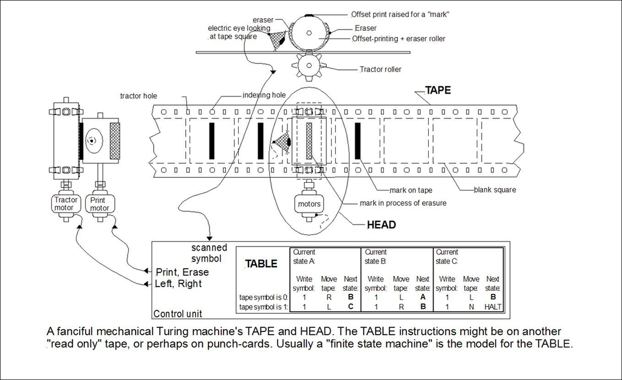

**Credit: https://en.wikipedia.org/wiki/File:Turing_machine_1.JPG**

# Turing Machine: Formal Definition

$\LARGE{M = (Q, \Sigma, q_0, F, \delta)}$

where

$Q$ is a finite set of states

$\Sigma$ is the finite tape alphabet

$q_0$ is the initial state

$F\subseteq Q$ is the set of final states

$\delta\subseteq(Q\times\Sigma)\times(Q\times\Sigma\times\{L,N,R\})$ is the transition function

# Turing Machine Rules

At each step of the computation:

- Each tape square records exactly one symbol, $\sigma_A\in\Sigma$
- $M$ is in exactly one state $q_A\in Q$
- Tape head scans exactly one square
- $M$ reads $\sigma_A$ and consults $\delta$ for which …
  - symbol $\sigma_B$ to write to the current tape square,
  - direction (**L**eft, **N**one, or **R**ight) to move the tape head, and
  - state $q_B$ is next

# Alan Turing

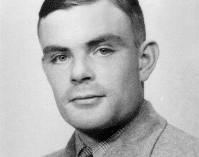

- “On Computable Numbers, With an Application to the Entscheidungsproblem” (1936)
  - Latter due to Hilbert and Ackermann in 1928
  - Mechanically decide whether a formula is provable from axioms
- Turing called them automatic machines or *a*-machines
- All done on paper (!) to formalize computability

# Nondeterministic Turing Machine

$\LARGE{M = (Q, \Sigma, \iota, F, \delta)}$

where

$Q$ is a finite set of states

$\Sigma$ is the finite tape alphabet

$\iota\in Q$ is the initial state

$F\subseteq Q$ is the set of accepting states

$\delta\subseteq(Q\times\Sigma)\times(Q\times\Sigma\times\{L,N,R\})$ is the transition **relation**

# What is nondeterminism?

- Faced with any choice, the nondeterministic machine guesses correctly
- Erik Demaine: “How do you engineer luck?”
- Nevertheless a useful theoretical limit
- Let’s encode the rules …

# Winning the Game

- Nondeterministic $M$ accepts $\mathcal{L}$ in polynomial time $T = Q(n)$
- Then $M$ scans no tape square beyond $T$
- Given input $w$, construct formula $A(w)$ satisfiable iff $M$ accepts $w$
- `z3.Not(A(w))` holds iff $w\not\in\mathcal{L}$

# Exactly one tape square scanned each step

Let $S_{s,t}$ be true iff square $s$ is scanned at time $t$. Then

$$B_t = (S_{1,t}\lor S_{2,t}\lor\cdots\lor S_{2,T})\land\left[\bigwedge_{1\leq i<j\leq T} (\lnot S_{i,t}\lor \lnot S_{j,t}) \right]$$

$$B = \bigwedge_{1\leq i\leq T} B_i$$

$$\lvert B\rvert = \mathcal{O}(T^3)$$

# Exactly one symbol in each square

Let $P_{s,t}^i$ be true iff tape square $s$ at step $t$ holds $\sigma_i$. Then

$$C_{s,t} = \bigvee_i P_{s,t}^i\land\left[\bigwedge_{1\leq j < k} (\lnot P_{s,t}^j\lor\lnot P_{s,t}^k)\right]$$

$$C = \bigwedge_{1\leq s,t\leq T} C_{s,t}$$

$$\lvert C\rvert = \mathcal{O}(T^2)$$

# Exactly one state at each step

Let $Q^i_t$ by true iff $M$ at step $t$ is in state $q_i$. Then

$$D_t = (Q_t^0\lor Q_t^1\lor\cdots)\land\left[\bigwedge_{1\leq i<j} (\lnot Q_t^i\lor\lnot Q_t^j)\right]$$

$$D = \bigwedge_{1\leq i\leq T} D_i$$

$$\lvert D\rvert = \mathcal{O}(T)$$

# *M* is properly initialized

$$E = Q_1^0\land S_{1,1}\land P_{1,1}^{i_1}\land\cdots\land P_{n,1}^{i_n}\land P_{n+1,1}^1\land P_{n+2}^2\land\cdots$$

where $w = \sigma_i\ldots\sigma_n$, $q_0$ is the start state, and $\sigma_1$ is the blank symbol.

Recall:

- $P^i_{s,t}$ iff tape square $s$ at step $t$ holds $\sigma_i$
- $Q^i_t$ iff at step $t$ the machine is in state $q_i$
- $S_{s,t}$ iff at time $t$ the machine scans square number $s$

$$\lvert E\rvert = \mathcal{O}(T)$$

# *M* adheres to transition relation

Let $F$, $G$, and $H$ constrain $P$, $Q$, and $S$ at each step $t$. For example

$$G_{i,j}^t = \bigwedge_{s=1}^{T} (\lnot Q_t^i\lor \lnot S_{s,t}\lor\lnot P_{s,t}^j\lor Q_{t+1}^k)$$

requires state $q_i$ scanning $\sigma_j$ to transition to appropriate $q_k$.

- $\lvert F\rvert = \mathcal{O}(T^2)$ — tape updates
- $\lvert G\rvert = \mathcal{O}(T^2)$ — legal state transitions
- $\lvert H\rvert = \mathcal{O}(T^3)$ — scan single square per step

# Reach an accept state

$$I = \bigvee_t (Q_t^{f_1}\lor\cdots\lor Q_t^{f_n})$$

where accept states are $F = {q_{f_1},\ldots,q_{f_n}}$.

$$\lvert I\rvert = \mathcal{O}(T)$$

# Another Logical Formula

$$A(w) = B\land C\land D\land E\land F\land G\land H\land I$$

- Declares successful computation history of polynomial size $Q(T)$
- *Enormous* formula
- … *but polynomially bounded!*
- So what have we accomplished?

# “The Complexity of Theorem-Proving Procedures”

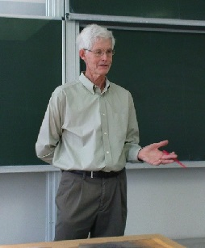

Stephen A. Cook, Image credit: Jiří JaníčekPokud, CC BY-SA 3.0

- 1971 paper showed any problem in NP at most polynomially harder than SAT
- Established SAT as the first problem in NP-complete
- We just walked through the proof

$$\forall p\in\mathbf{NP}, c\in\mathbf{NP}\mathrm{-complete}, p \leq_P c$$

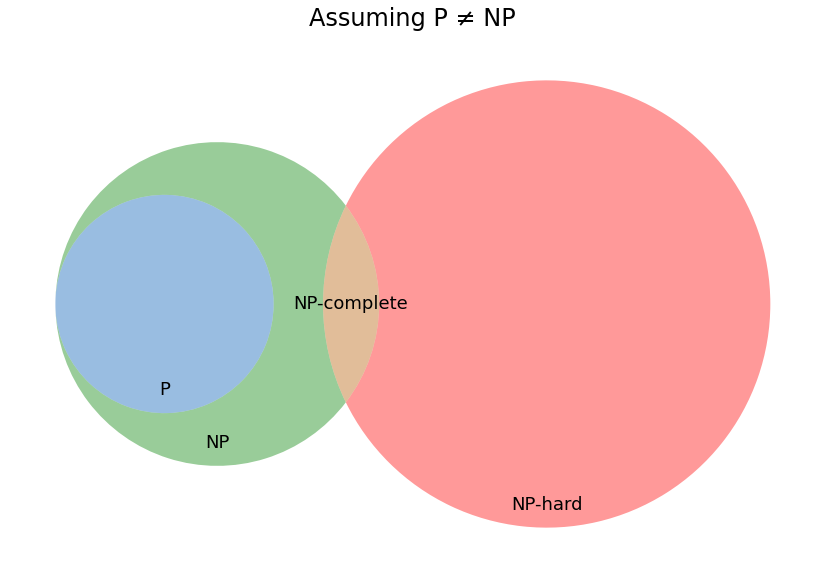

```python
plot_complexity_venn()
```

# In Conclusion

- Attacking the problem backwards motivates why SAT solvers matter
- Add this powerful technique to your bag of tricks
- P versus NP is one of the most important open problems in science